# Digi Data Visualization Series: Intro to ggplot2

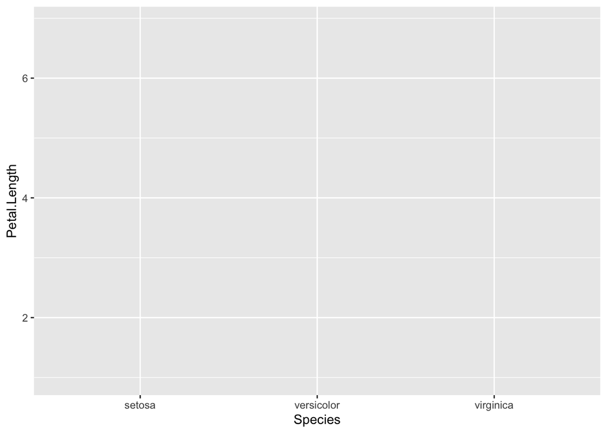

```r
#insert the aesthetic mappings after the call to data, specifying the x and y
ggplot(iris, aes(x = Species, y = Petal.Length))
```

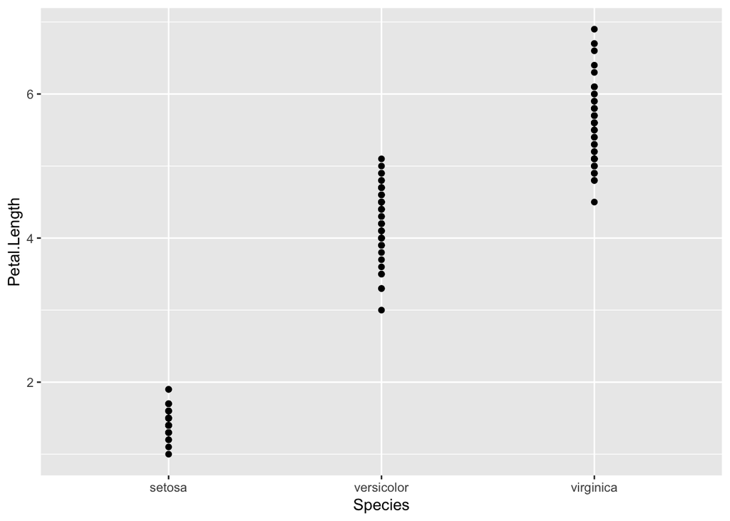

```r
#Now what is displayed? We will continue to add the aesthetic elements to be displayed


#adding geom_point() to map the data values as points onto the graphic
ggplot(iris, aes(x = Species, y = Petal.Length))+ geom_point()
```

# Boxplots using geom_boxplot() Boxplots are helpful for visualizing the distribution of data values and for comparing across different variables.

```r
head(iris) #inspect the data
```

```
##   Sepal.Length Sepal.Width Petal.Length Petal.Width Species
## 1          5.1         3.5          1.4         0.2  setosa
## 2          4.9         3.0          1.4         0.2  setosa
## 3          4.7         3.2          1.3         0.2  setosa
## 4          4.6         3.1          1.5         0.2  setosa
## 5          5.0         3.6          1.4         0.2  setosa
## 6          5.4         3.9          1.7         0.4  setosa
```

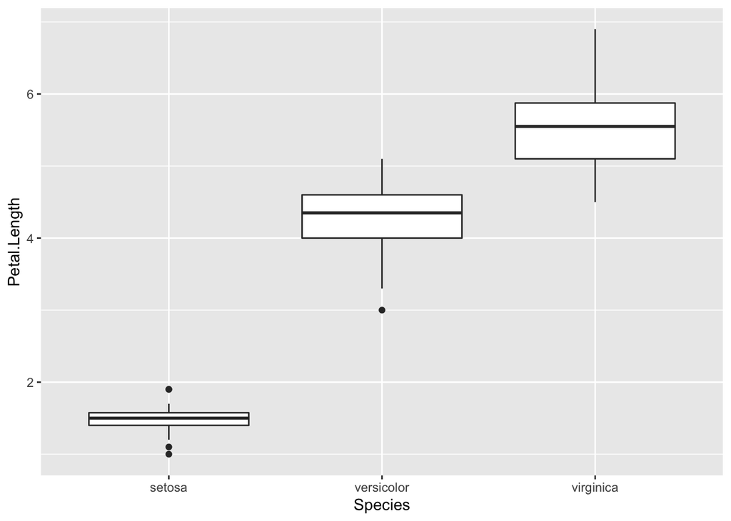

```r
#create a boxplot using geom_boxplot
ggplot(iris, aes(x = Species, y = Petal.Length)) +geom_boxplot()
```

### Line graphs with ggplot using geom_line

Now we will use a built in dataset in ggplot: economics data. Time series data works especially well with line graphs.

```r
#inspect the data
head(economics)
```

```
## # A tibble: 6 x 6
##   date         pce    pop psavert uempmed unemploy
##   <date>     <dbl>  <dbl>   <dbl>   <dbl>    <dbl>
## 1 1967-07-01  507. 198712    12.6     4.5     2944
## 2 1967-08-01  510. 198911    12.6     4.7     2945
## 3 1967-09-01  516. 199113    11.9     4.6     2958
## 4 1967-10-01  512. 199311    12.9     4.9     3143
## 5 1967-11-01  517. 199498    12.8     4.7     3066
## 6 1967-12-01  525. 199657    11.8     4.8     3018
```

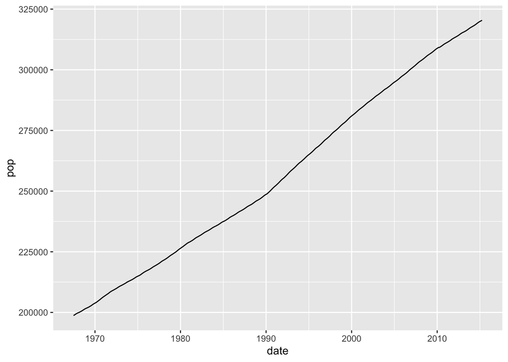

```r
ggplot(economics, aes(x = date, y = pop)) + geom_line()
```

### Creating barplots and scatterplots

Use geom_bar() to create a barplot; note: you must include the argument inside geom_bar(stat = “identity”) to tell R to use the y values for the height of the bars.

Use geom_point() to create the scatterplot.

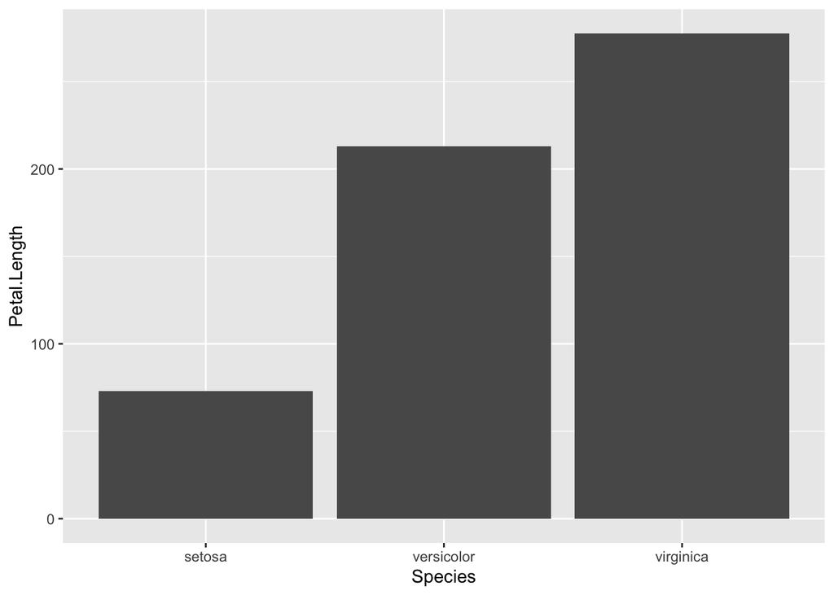

```r
#barplots are another useful visualization for comparisons between different groups.
ggplot(iris, aes(x = Species, y = Petal.Length)) +geom_bar(stat = "identity")
```

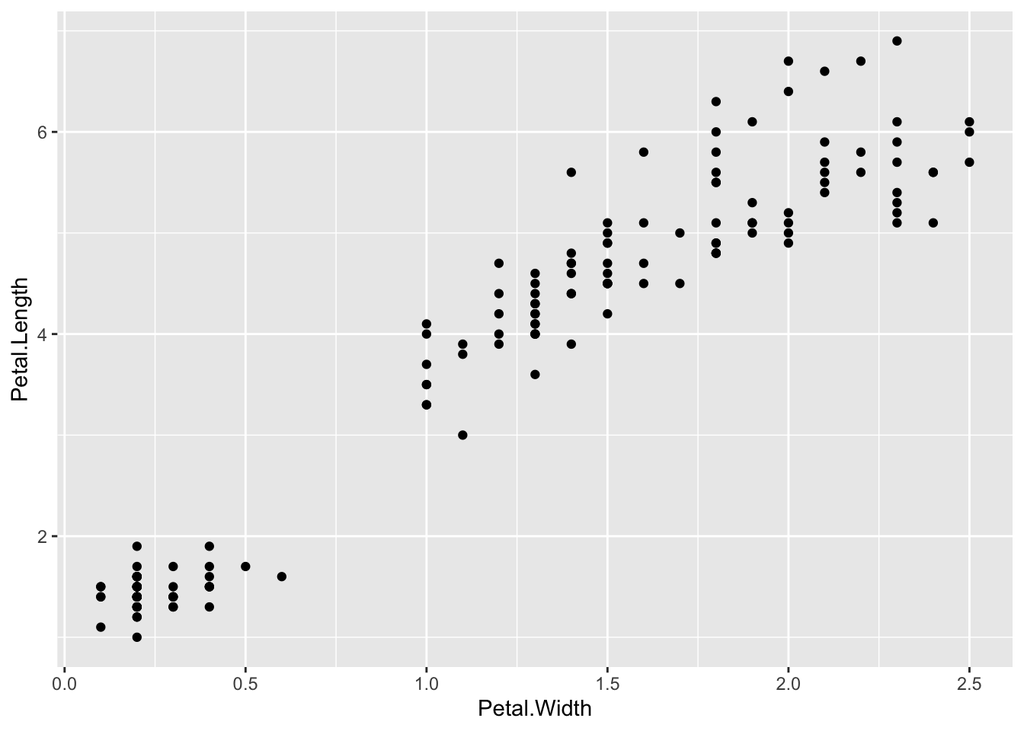

```r
#Scatterplots are a great option for visualizing multiple variables.
ggplot(iris, aes(x = Petal.Width, y = Petal.Length)) +geom_point()
```

### Colors, shapes, and themes

Ggplot also includes built in colors and options for creating distinctive visualizations. Themes allow you to control different aspects of distinctive color combinations, fonts, etc.

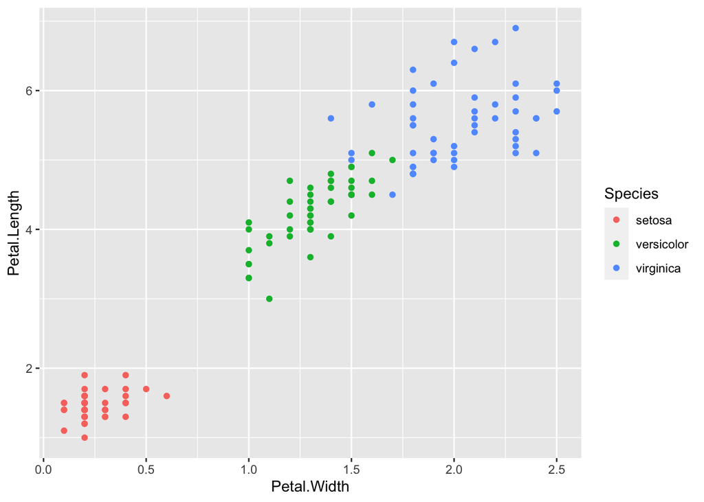

```r
#now let's use color to refine the visualization further, comparing by species
ggplot(iris, aes(x = Petal.Width, y = Petal.Length, color = Species)) +geom_point()
```

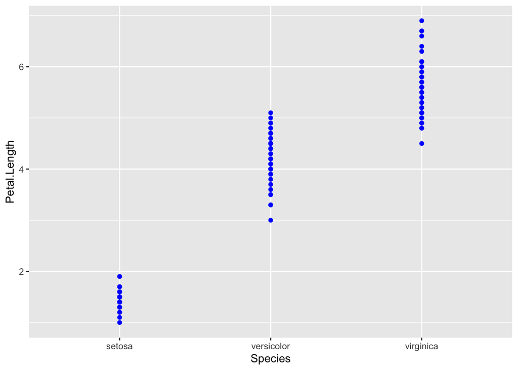

```r
#colors can also be set for the whole plot or by variables

ggplot(iris, aes(x= Species, y = Petal.Length))+ geom_point(color = 'blue')
```

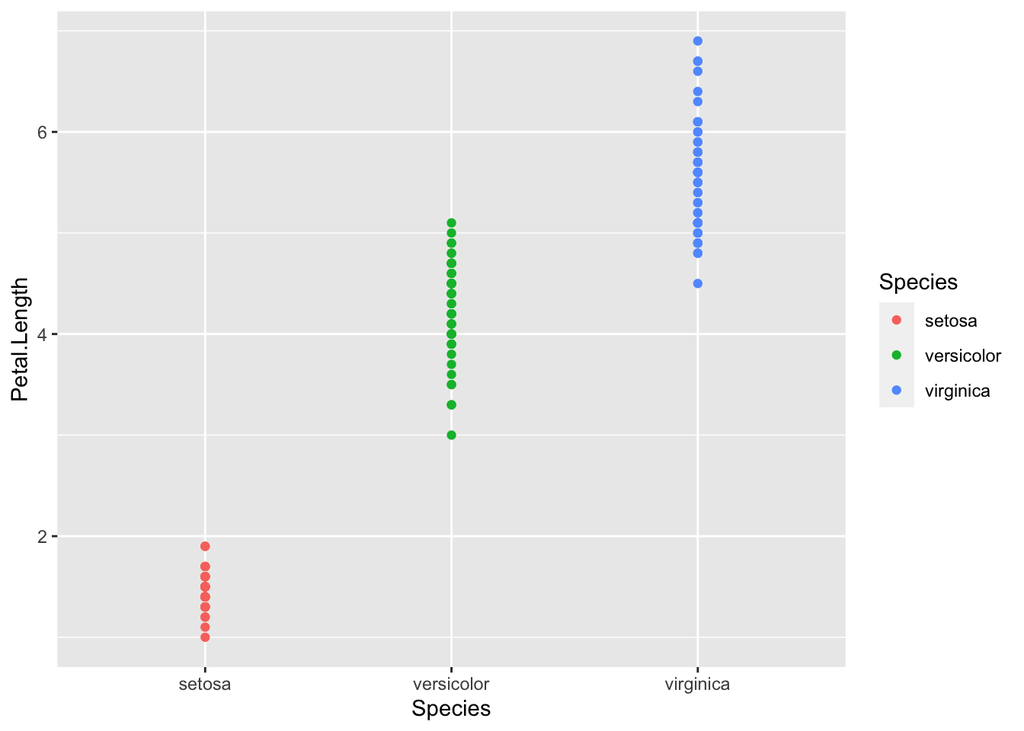

```r
#now adjust it to color by a specific variable: species
ggplot(iris, aes(x= Species, y = Petal.Length))+ geom_point(aes(color = Species))
```

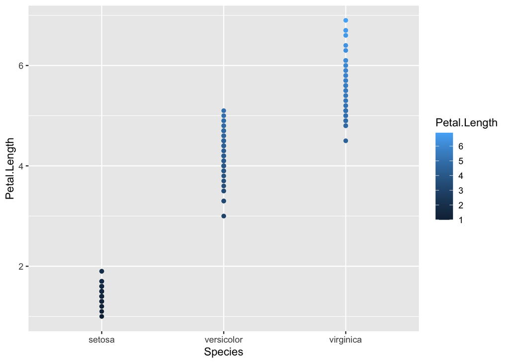

```r
#switch out Species for Petal.Length
ggplot(iris, aes(x= Species, y = Petal.Length))+ geom_point(aes(color = Petal.Length))
```

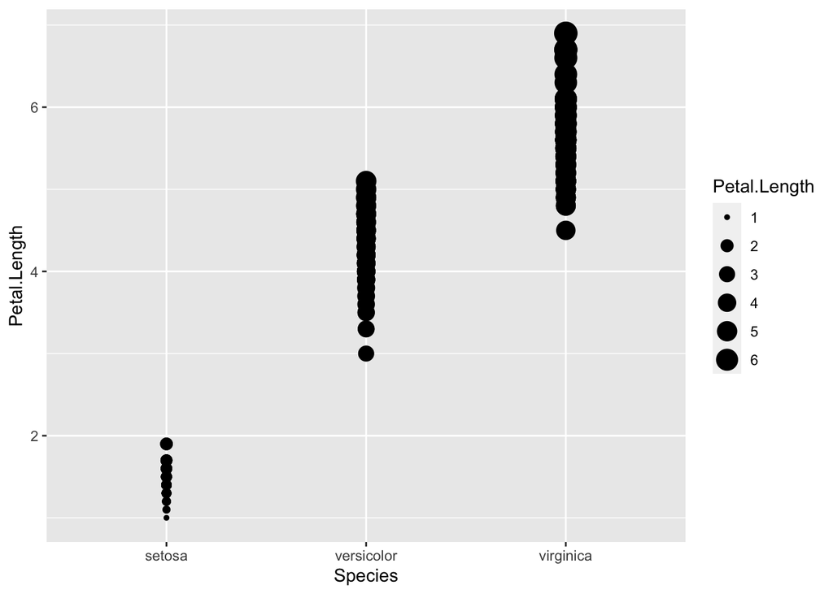

```r
#what is the difference between the two?
##ggplot is automatically assigning a unique color to each value of the petal.length variable with the same scale of colors for each species
#when color = species, all values for each species are given a specific color


#another option is to use size to highlight a specific variable:
ggplot(iris, aes(x= Species, y = Petal.Length)) + geom_point(aes(size = Petal.Length))
```

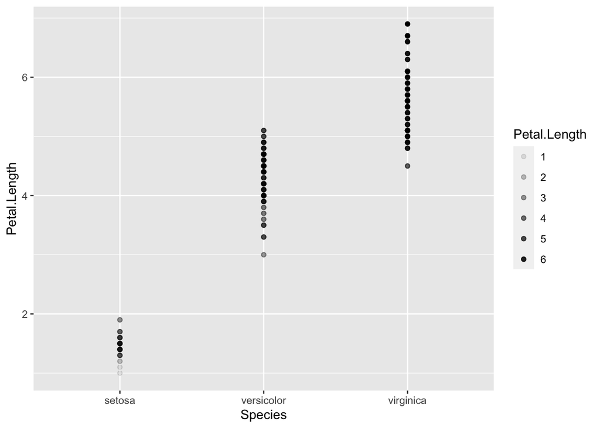

```r
#adjusting transparency of points through the alpha aesthetic
ggplot(iris, aes(x= Species, y = Petal.Length)) + geom_point(aes(alpha = Petal.Length))
```

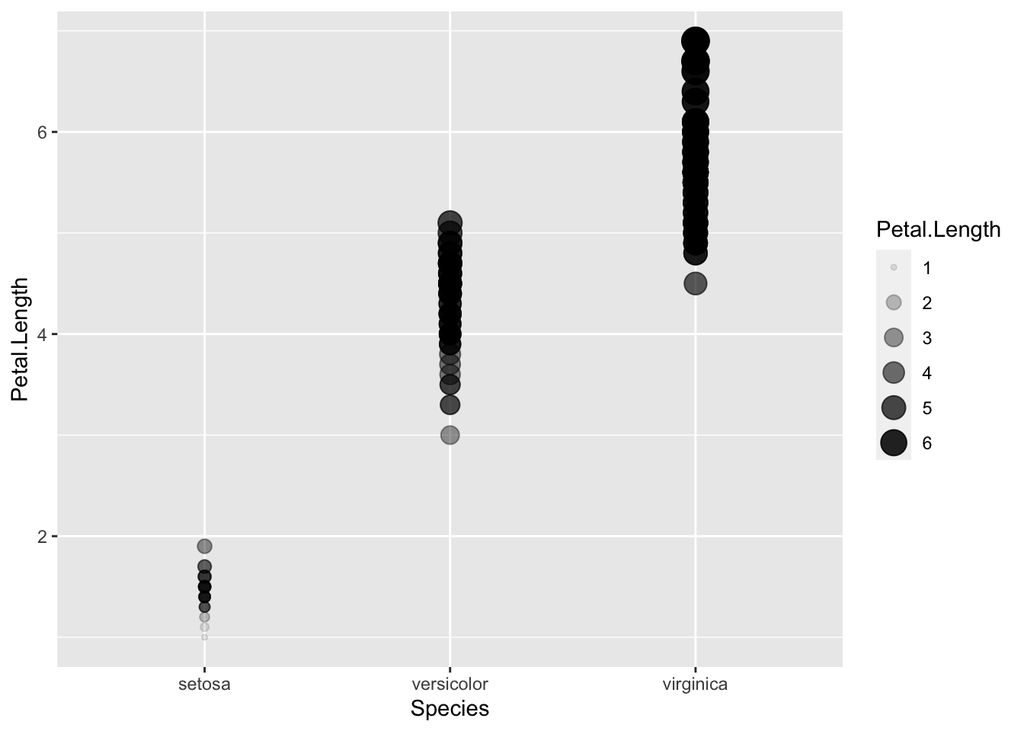

```r
#utilize shapes to represent different variables, using the aes shape = VARIABLENAME
ggplot(iris, aes(x= Species, y = Petal.Length)) + geom_point(aes(alpha = Petal.Length, size = Petal.Length))
```

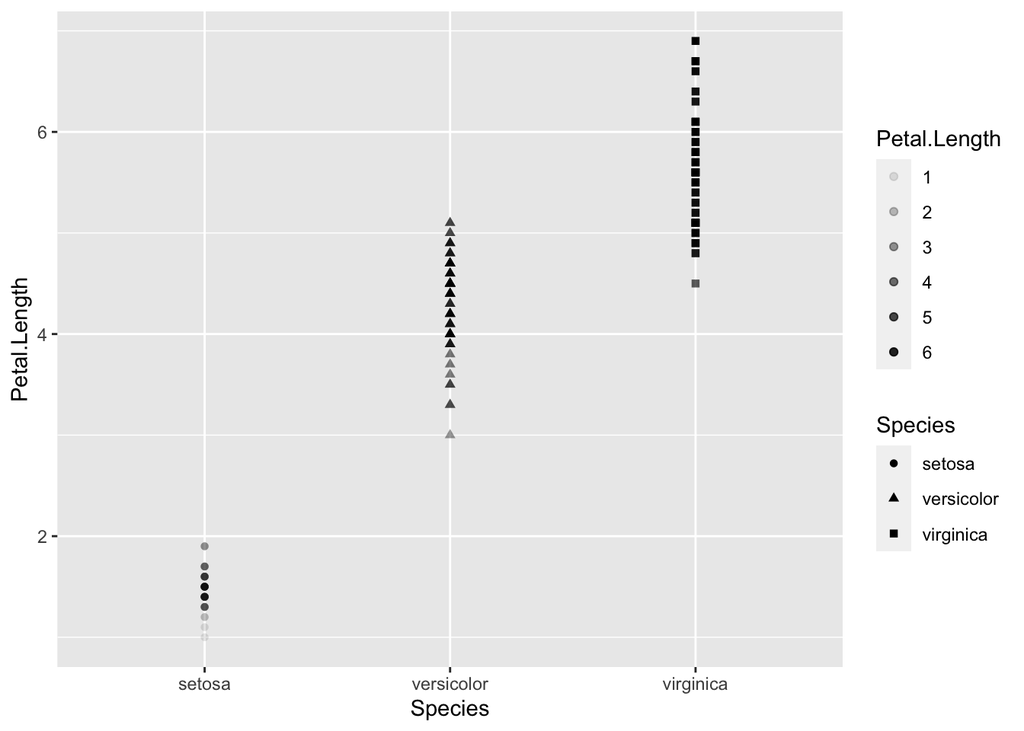

```r
#combine both
ggplot(iris, aes(x= Species, y = Petal.Length)) + geom_point(aes(alpha = Petal.Length, shape = Species))
```

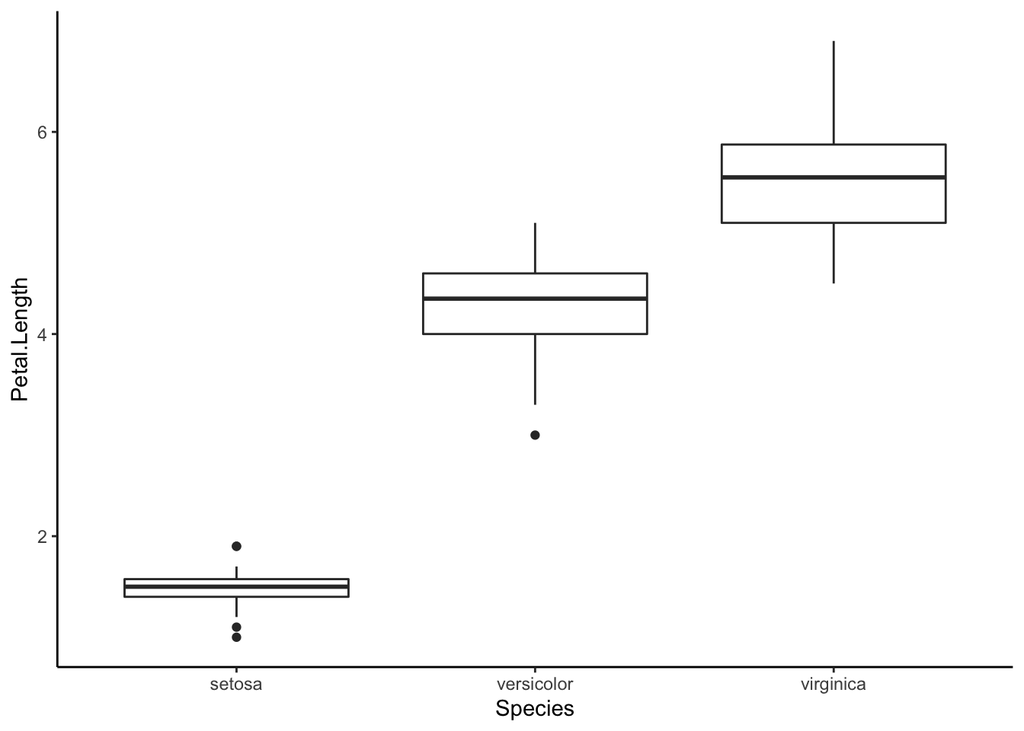

```r
#try out different themes, which are added on with the
#function theme_name(). The example below uses theme_classic.
ggplot(iris, aes(x = Species, y = Petal.Length)) +geom_boxplot() + theme_classic()
```

Additional options: adding axis labels, titles, and themes. These are the functions used to add titles and axis labels:  
- ggtitle(YourTitleHere) #main title  
- xlab(XaxisLabelHere) #x axis label  
- ylab(XaxisLabelHere) #for the y axis label  
- labs(YourLabelsHere) #for the main title, axis labels and legend titles

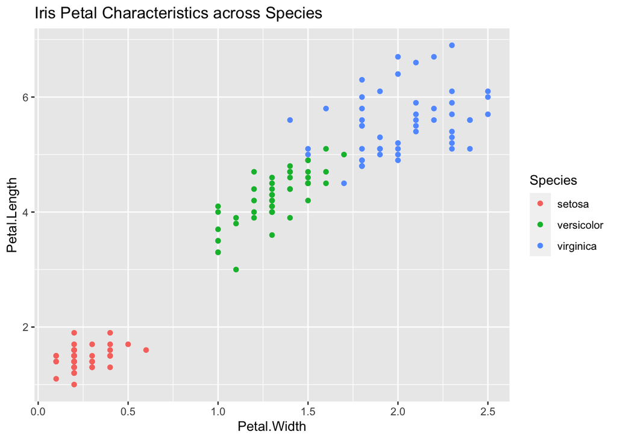

```r
#add in main title
ggplot(iris, aes(x = Petal.Width, y = Petal.Length, color = Species)) +geom_point() + ggtitle("Iris Petal Characteristics across Species")
```

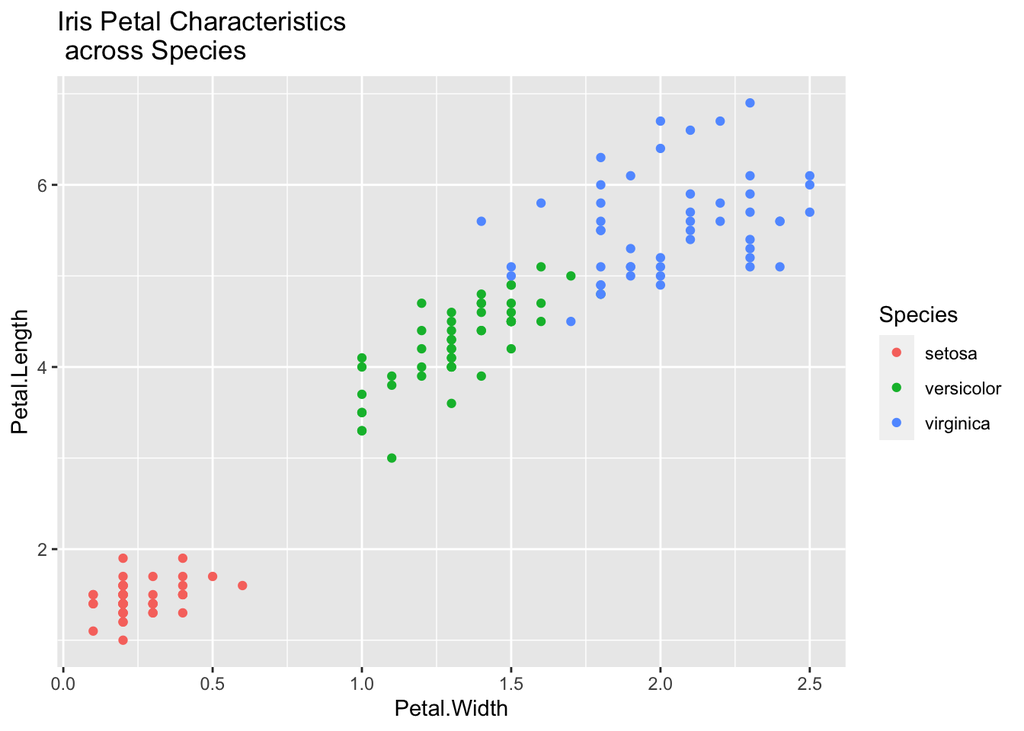

```r
#add in main title with a line break
ggplot(iris, aes(x = Petal.Width, y = Petal.Length, color = Species)) +geom_point() + ggtitle("Iris Petal Characteristics \n across Species")
```

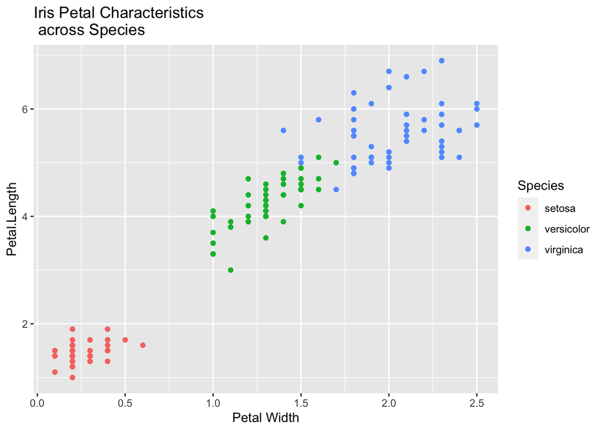

```r
#add axis labels
ggplot(iris, aes(x = Petal.Width, y = Petal.Length, color = Species)) +geom_point() + ggtitle("Iris Petal Characteristics \n across Species") +xlab("Petal Width")
```

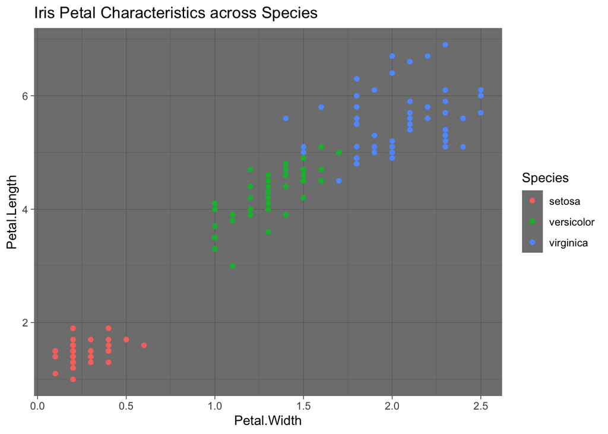

```r
#your turn! add in the y axis label.



#more theme options
ggplot(iris, aes(x = Petal.Width, y = Petal.Length, color = Species)) +geom_point() + ggtitle("Iris Petal Characteristics across Species") +theme_dark()
```

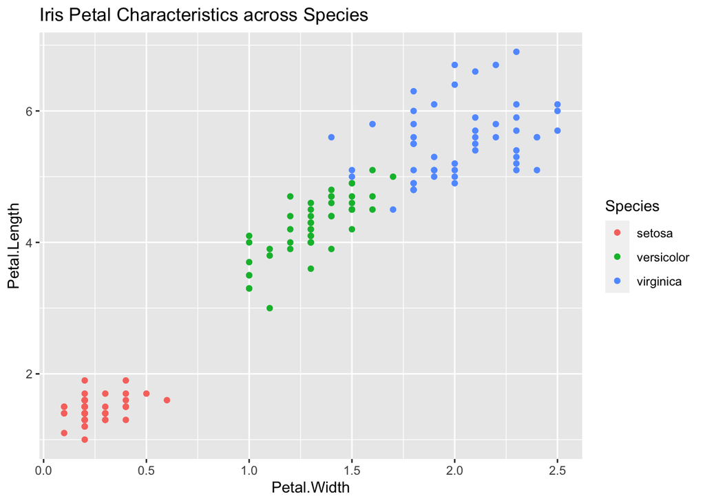

```r
ggplot(iris, aes(x = Petal.Width, y = Petal.Length, color = Species)) +geom_point() + ggtitle("Iris Petal Characteristics across Species") +theme_grey()
```

### Web-Based Resources

- [Ggplot2: Elegant Graphics for Data Analysis](https://ggplot2-book.org/index.html), by Wickam et al.
- [Ggplot2 cheat sheet](https://www.maths.usyd.edu.au/u/UG/SM/STAT3022/r/current/Misc/data-visualization-2.1.pdf)
- [Plotting anything with ggplot2 webinar](https://www.youtube.com/watch?v=h29g21z0a68)
- [R Graphics Cookbook](https://r-graphics.org/.)

### Resources at UGA

- Linked-in Learning Tutorials
- Previous and upcoming DigiLab Tutorials
- DigiLab Data Consultations
- R Ladies Athens

Questions, comments, or suggestions? Get in touch: - katherine.kuiper25@uga.edu - kirelandkuiper.com

### Coming up next:

- ```
  Advanced Ggplot2 on October 6th
  ```

- ```
  Introduction to network analysis on October 13th
  ```

- ```
  Network analysis in Cytoscape on October 20th
  ```

- ```
  Mapping Geographical Data on October 27th
  ```

### Works Cited

Anderson, Edgar. 1935. The irises of the Gaspe Peninsula, Bulletin of the American Iris Society, 59, 2–5.  
Chang, Winston. 2021. [R Graphics Cookbook.](https://r-graphics.org/.)  
Dawson, Robert J. MacG. 1995. The ‘Unusual Episode’ Data Revisited. Journal of Statistics Education, 3. doi: 10.1080/10691898.1995.11910499.  
De Vries, Andrie, and Joris Meys. 2015. R For Dummies. John Wiley & Sons.  
Fay, Colin. Visualizing text data with ggplot2. Hill, Asha. 2018. 9 Useful R Data Visualization Packages for Any Discipline. Mode. https://mode.com/blog/r-data-visualization-packages/  
Mejia, Mandy. 2013. 10 reasons to switch to ggplot. mandymejia.com

Pandey, Parul. 2019. A Comprehensive Guide to Data Visualization in R For Beginners. Towardsdatascience.com  
Paradis, Emmanuel. 2005. R For Beginners.  
Pederson, Thomas Lin. 2020. [plotting anything with ggplot2 webinar.](https://www.youtube.com/watch?v=h29g21z0a68)  
R Studio Team. 2018. [Ggplot2 Cheat Sheet](https://www.maths.usyd.edu.au/u/UG/SM/STAT3022/r/current/Misc/data-visualization-2.1.pdf)  
Wickam, Hadley. 2010. A layered grammar of graphics. Journal of Computational and Graphical Statistics.  
Wickam, Hadley, Danielle Navarro, and Thomas Lin Pederson. 2021. [ggplot2: Elegant Graphics for Data Analysis.](https://ggplot2-book.org/index.html)